# SPC_HW1

2014-10451

2020년 10월 7일

# Question 6.6 (a)

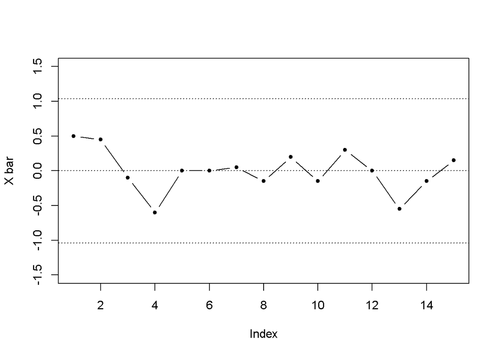

```r
table_6e3<-matrix(c(
  2.5,0.5,2.0,-1.0,1.0,-1.0,0.5,1.5,0.5,-1.5,
  0.0,0.0,0.5,1.0,1.5,1.0,-1.0,1.0,1.5,-1.0,
  1.5,1.0,1.0,-1.0,0.0,-1.5,-1.0,-1.0,1.0,-1.0,
  0.0,0.5,-2.0,0.0,-1.0,1.5,-1.5,0.0,-2.0,-1.5,
  0.0,0.0,0.0,-0.5,0.5,1.0,-0.5,-0.5,0.0,0.0,
  1.0,-0.5,0.0,0.0,0.0,0.5,-1.0,1.0,-2.0,1.0,
  1.0,-1.0,-1.0,-1.0,0.0,1.5,0.0,1.0,0.0,0.0,
  0.0,-1.5,-0.5,1.5,0.0,0.0,0.0,-1.0,0.5,-0.5,
  -2.0,-1.5,1.5,1.5,0.0,0.0,0.5,1.0,0.0,1.0,
  -0.5,3.5,0.0,-1.0,-1.5,-1.5,-1.0,-1.0,1.0,0.5,
  0.0,1.5,0.0,0.0,2.0,-1.5,0.5,-0.5,2.0,-1.0,
  0.0,-2.0,-0.5,0.0,-0.5,2.0,1.5,0.0,0.5,-1.0,
  -1.0,-0.5,-0.5,-1.0,0.0,0.5,0.5,-1.5,-1.0,-1.0,
  0.5,1.0,-1.0,-0.5,-2.0,-1.0,-1.5,0.0,1.5,1.5,
  1.0,0.0,1.5,1.5,1.0,-1.0,0.0,1.0,-2.0,-1.5),
  nrow=15,ncol=10,byrow=T)
colnames(table_6e3) <- paste0("X",1:10)
n <- 10
mu0 <- 0
c4_10 <- 0.9727

s_bar <- mean(apply(table_6e3,1,sd))
sigma0_hat <- s_bar/c4_10
UCL_xbar <- mu0 + 3*sigma0_hat/sqrt(n)
CL_xbar <- mu0
LCL_xbar <- mu0 - 3*sigma0_hat/sqrt(n)

plot(apply(table_6e3,1,mean), type="b", pch=20, ylab="X bar", ylim=c(-1.5,1.5))
abline(h=UCL_xbar, lty="dotted")
abline(h=CL_xbar, lty="dotted")
abline(h=LCL_xbar, lty="dotted")
```

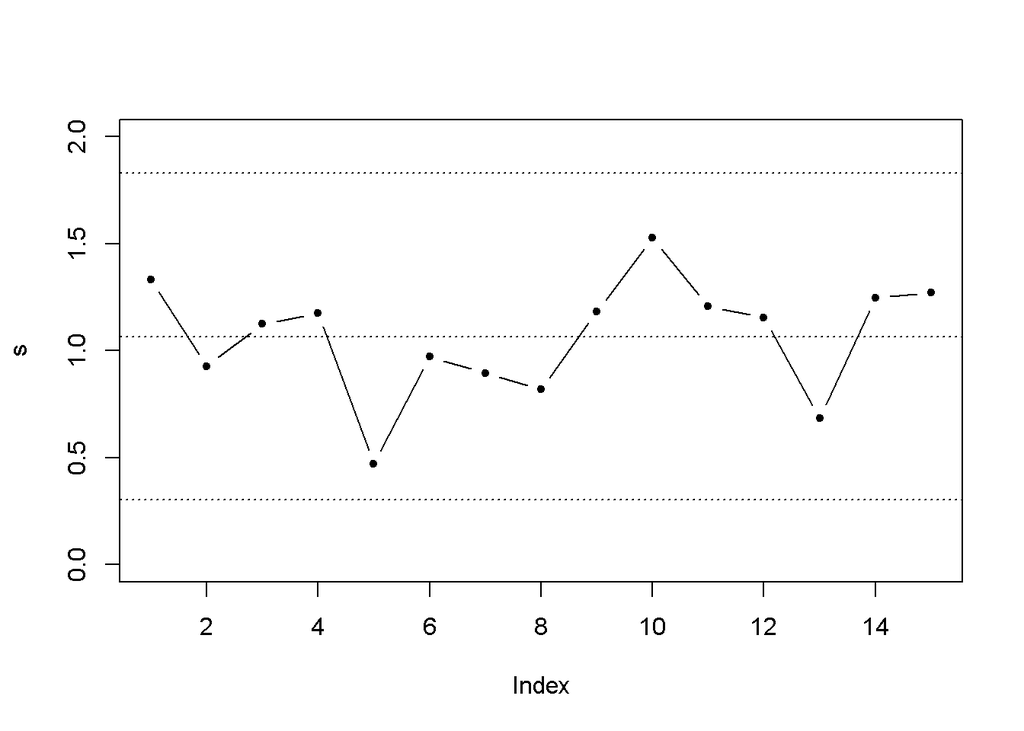

```r
UCL_s <- s_bar + 3*sqrt(1-c4_10^2)*sigma0_hat
CL_s <- s_bar
LCL_s <- s_bar - 3*sqrt(1-c4_10^2)*sigma0_hat
plot(apply(table_6e3,1,sd), type="b", pch=20, ylab="s", ylim=c(0,2))
abline(h=UCL_s, lty="dotted")
abline(h=CL_s, lty="dotted")
abline(h=LCL_s, lty="dotted")
```

모든 sample index에 대하여 sample 특성치 X_bar, s가 [LCL,UCL] 구간을 벗어나지 않으므로 In-Control 상태라고 볼 수 있다.

# Question 6.6 (b)

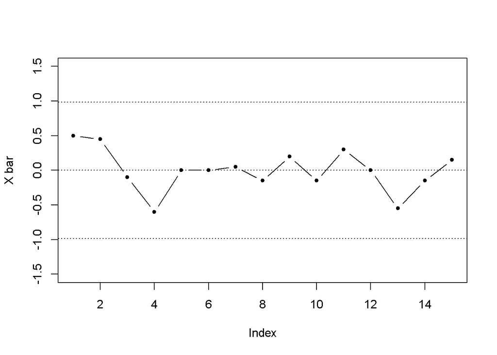

```r
rg <- function(x){
  return(max(x)-min(x))
}

d2_10 <- 3.078
d3_10 <- 0.797
R_bar <- mean(apply(table_6e3,1,rg))
sigma0_hat_R <- R_bar/d2_10

UCL_xbar_R <- mu0 + 3*sigma0_hat_R/sqrt(n)
CL_xbar_R <- mu0
LCL_xbar_R <- mu0 - 3*sigma0_hat_R/sqrt(n)
plot(apply(table_6e3,1,mean), type="b", pch=20, ylab="X bar", ylim=c(-1.5,1.5))
abline(h=UCL_xbar_R, lty="dotted")
abline(h=CL_xbar_R, lty="dotted")
abline(h=LCL_xbar_R, lty="dotted")
```

# Question 6.6 (c)

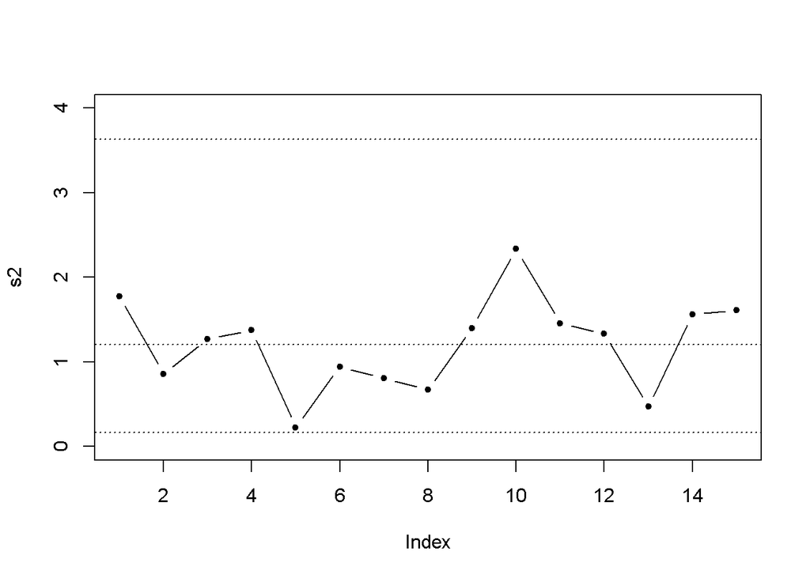

```r
alpha=0.0027
s2_bar <- mean(apply(table_6e3,1,var))

UCL_s2 <-qchisq(1-alpha/2,df=n-1)*s2_bar/(n-1)
CL_s2 <-s2_bar
LCL_s2 <-qchisq(alpha/2,df=n-1)*s2_bar/(n-1)

plot(apply(table_6e3,1,var), type="b", pch=20, ylab="s2", ylim=c(0,4))
abline(h=UCL_s2, lty="dotted")
abline(h=CL_s2, lty="dotted")
abline(h=LCL_s2, lty="dotted")
```

s2를 sample index의 특성치로 이용하는 경우, 즉 w=s2인 경우 target(center line)은 mu_w=mu_s2=sigma0^2이다. 여기서, sigma0^2는 unknown이므로 추정치로 s2_bar을 plug-in하여 CL=s2_bar이다. 한편, UCL과 LCL을 구하기 위해서는 아래 식을 풀면 구할 수 있고, 구한 결과는 코드에 나와있다. alpha = Pr(s2 in [LCL,UCL] given X ~ NID(mu0,sigma0^2))

plotting 결과 s chart와 비교해 공정이 In-control임을 보여주며, 개형이 거의 비슷함을 알 수 있다. 따라서 산포에 대한 특성치를 분석하고자 하는 경우 R과 s chart만 이용하면 충분할 것으로 보인다.

# Question 6.9 (a)

```r
table_6e4 <- matrix(c(138.1,110.8,138.7,137.4,125.4,
149.3,142.1,105.0,134.0,92.3,
115.9,135.6,124.2,155.0,117.4,
118.5,116.5,130.2,122.6,100.2,
108.2,123.8,117.1,142.4,150.9,
102.8,112.0,135.0,135.0,145.8,
120.4,84.3,112.8,118.5,119.3,
132.7,151.1,124.0,123.9,105.1,
136.4,126.2,154.7,127.1,173.2,
135.0,115.4,149.1,138.3,130.4,
139.6,127.9,151.1,143.7,110.5,
125.3,160.2,130.4,152.4,165.1,
145.7,101.8,149.5,113.3,151.8,
138.6,139.0,131.9,140.2,141.1,
110.1,114.6,165.1,113.8,139.6,
145.2,101.0,154.6,120.2,117.3,
125.9,135.3,121.5,147.9,105.0,
129.7,97.3,130.5,109.0,150.5,
123.4,150.0,161.6,148.4,154.2,
144.8,138.3,119.6,151.8,142.7),
nrow=20, ncol=5, byrow="T")
summary(table_6e4)
```

```
##        V1              V2              V3              V4
##  Min.   :102.8   Min.   : 84.3   Min.   :105.0   Min.   :109.0
##  1st Qu.:119.9   1st Qu.:111.7   1st Qu.:123.4   1st Qu.:122.0
##  Median :131.2   Median :125.0   Median :131.2   Median :136.2
##  Mean   :129.3   Mean   :124.2   Mean   :135.3   Mean   :133.7
##  3rd Qu.:138.8   3rd Qu.:138.5   3rd Qu.:149.9   3rd Qu.:144.8
##  Max.   :149.3   Max.   :160.2   Max.   :165.1   Max.   :155.0
##        V5
##  Min.   : 92.3
##  1st Qu.:115.6
##  Median :135.0
##  Mean   :131.9
##  3rd Qu.:150.6
##  Max.   :173.2
```

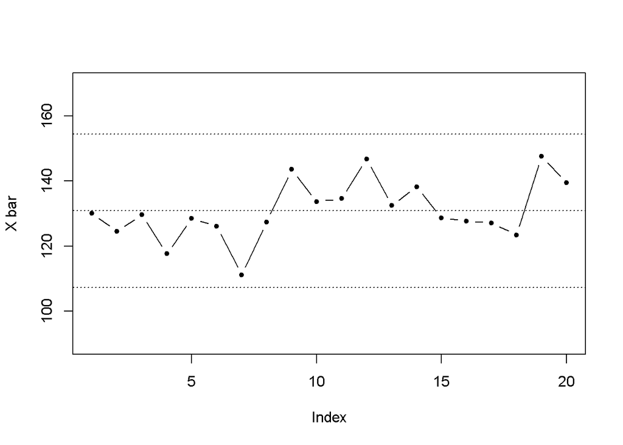

```r
n <- 5
d2_5 <- 2.326
d3_5 <- 0.864

R_bar <- mean(apply(table_6e4,1,rg))
sigma0_hat_R <- R_bar/d2_5
x_barbar <-mean(apply(table_6e4,1,mean))

UCL_xbar <- x_barbar + 3*(sigma0_hat_R)/sqrt(n)
CL_xbar <- x_barbar
LCL_xbar <- x_barbar - 3*(sigma0_hat_R)/sqrt(n)

plot(apply(table_6e4,1,mean), type="b", pch=20, ylab="X bar", ylim=c(90,170))
abline(h=UCL_xbar, lty="dotted")
abline(h=CL_xbar, lty="dotted")
abline(h=LCL_xbar, lty="dotted")
```

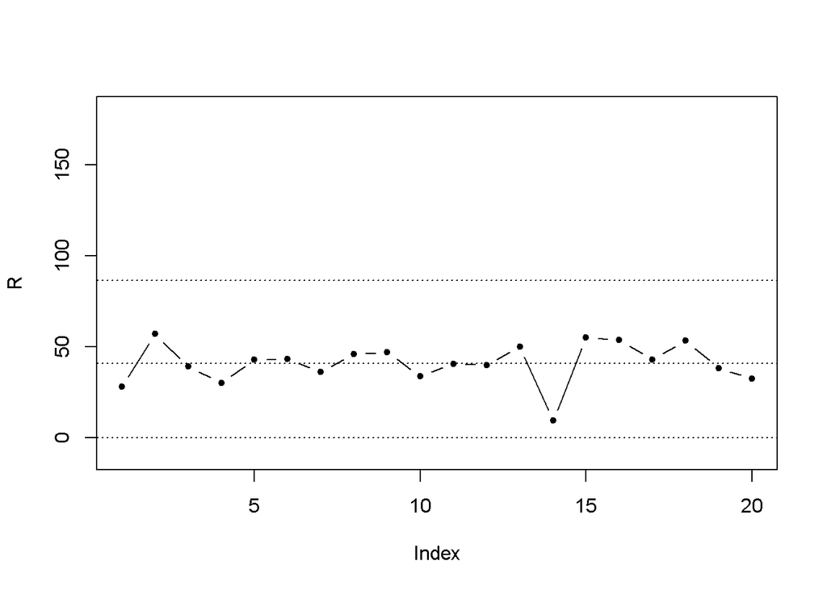

```r
UCL_R <- R_bar + 3*R_bar*d3_5/d2_5
CL_R <- R_bar
LCL_R <- max((R_bar-3*R_bar*d3_5/d2_5), 0)

plot(apply(table_6e4,1,rg), type="b", pch=20, ylab="R", ylim=c(-10,180))
abline(h=UCL_R, lty="dotted")
abline(h=CL_R, lty="dotted")
abline(h=LCL_R, lty="dotted")
```

# Question 6.9 (b)

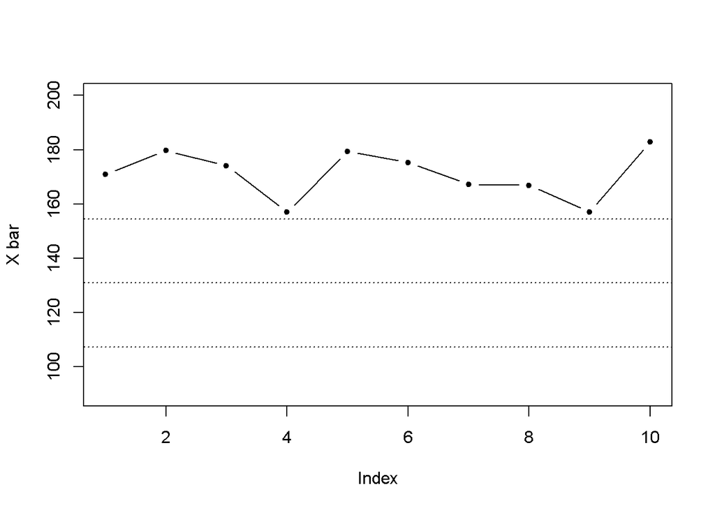

```r
table_6e5 <- matrix(c(131.0,184.8,182.2,143.3,212.8,
181.3,193.2,180.7,169.1,174.3,
154.8,170.2,168.4,202.7,174.4,
157.5,154.2,169.1,142.2,161.9,
216.3,174.3,166.2,155.5,184.3,
186.9,180.2,149.2,175.2,185.0,
167.8,143.9,157.5,171.8,194.9,
178.2,186.7,142.4,159.4,167.6,
162.6,143.6,132.8,168.9,177.2,
172.1,191.7,203.4,150.4,196.3),
nrow=10, ncol=5, byrow=T)

plot(apply(table_6e5,1,mean), type="b", pch=20, ylab="X bar", ylim=c(90,200))
abline(h=UCL_xbar, lty="dotted")
abline(h=CL_xbar, lty="dotted")
abline(h=LCL_xbar, lty="dotted")
```

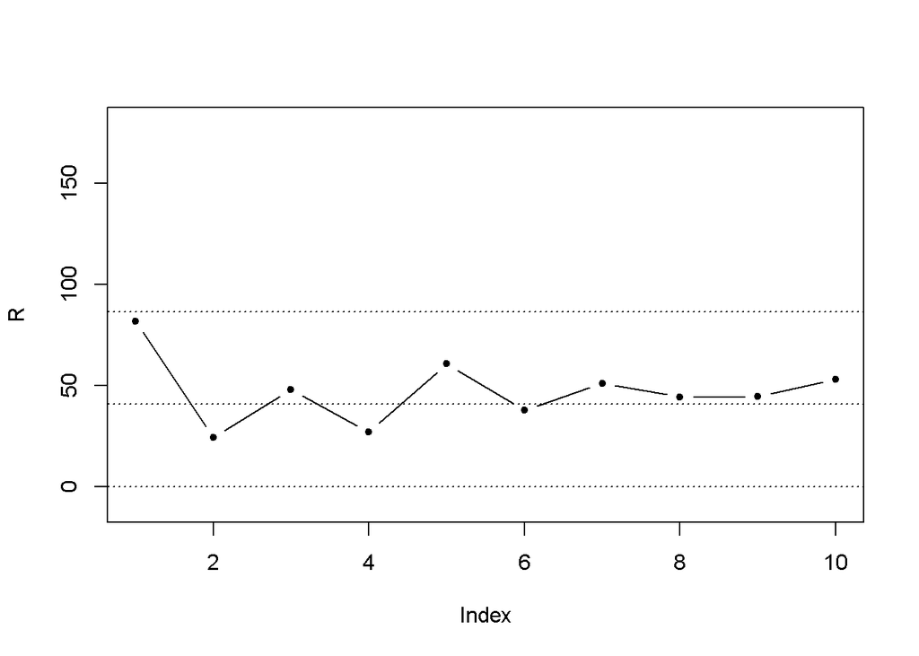

```r
plot(apply(table_6e5,1,rg), type="b", pch=20, ylab="R", ylim=c(-10,180))
abline(h=UCL_R, lty="dotted")
abline(h=CL_R, lty="dotted")
abline(h=LCL_R, lty="dotted")
```

new sample에 대하여 만일 공정이 In control 상태라면 기존 (a)에서 구한 LCL, CL, UCL 구간 안 또는 근처 sample 특성치가 분포하여야 한다(LCL, UCL은 sample에 따라 달라지는 값이므로 new sample을 고려하기 전과 비교할 때 정확히 같지는 않더라도 비슷할 것) 그러나, x_bar chart를 보면 new sample의 x_bar 특성치들은 전체적으로 상방 이동하여 평균 모수 mu0 -> mu1(>mu0)으로 shifting된 것으로 보인다. 따라서, new sample을 관찰할 때 이 공정은 In control 상태라고 볼 수 없다. 한편, R chart는 new sample의 R 특성치가 기존 LCL, UCL 사이에 들어가는 것으로 보아 산포에 관련한 shifting은 없다고 생각된다.

# Question 6.9 (c)

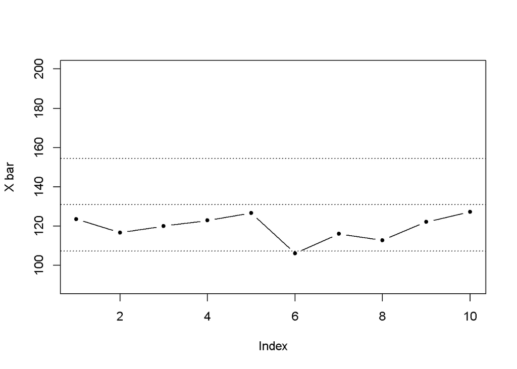

```r
table_6e6 <- matrix(c(131.5,143.1,118.5,103.2,121.6,111.0,127.3,110.4,91.0,143.9,
129.8,98.3,134.0,105.1,133.1,
145.2,132.8,106.1,131.0,99.2,
114.6,111.0,108.8,177.5,121.6,
125.2,86.4,64.4,137.1,117.5,
145.9,109.5,84.9,129.8,110.6,
123.6,114.0,135.4,83.2,107.6,
85.8,156.3,119.7,96.2,153.0,
107.4,148.7,127.4,125.0,127.5),
nrow=10,ncol=5,byrow="T")

plot(apply(table_6e6,1,mean), type="b", pch=20, ylab="X bar", ylim=c(90,200))
abline(h=UCL_xbar, lty="dotted")
abline(h=CL_xbar, lty="dotted")
abline(h=LCL_xbar, lty="dotted")
```

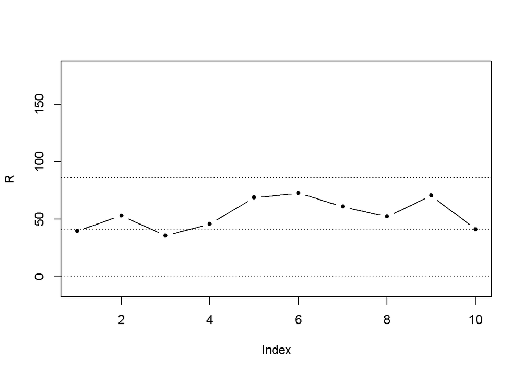

```r
plot(apply(table_6e6,1,rg), type="b", pch=20, ylab="R", ylim=c(-10,180))
abline(h=UCL_R, lty="dotted")
abline(h=CL_R, lty="dotted")
abline(h=LCL_R, lty="dotted")
```

# Question 6.57

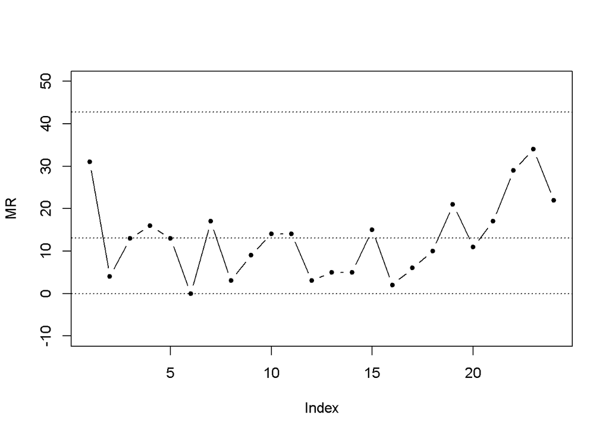

```r
table_4e8 <- matrix(c(
  81,56,82,
  112,73,66,
  108,62,76,
  95,61,66,
  111,68,78,
  98,65,71,
  98,64,84,
  115,72,61,
  112,72,77,
  103,63,74,
  117,72,59,
  103,71,85,
  100,65,64,
  105,64,71,
  100,71,85,
  115,66,65,
  113,84,78,
  107,71,76,
  117,74,90,
  96,68,81,
  107,60,72,
  90,57,89,
  119,69,61,
  85,59,77,
  107,70,83),
  nrow=25,ncol=3,byrow="T")
colnames(table_4e8) <- c("Systolic", "Diastolic","PulseRate")

n=25
d2_2 <- 1.128
d3_2 <- 0.853

MR <- abs(table_4e8[2:n,"Systolic"] - table_4e8[1:(n-1),"Systolic"])
MR_bar <- mean(MR)
UCL_MR <- MR_bar + 3*MR_bar*d3_2/d2_2
CL_MR <- MR_bar
LCL_MR <- max((MR_bar - 3*MR_bar*d3_2/d2_2),0)

plot(MR, type="b", pch=20, ylab="MR", ylim=c(-10,50))
abline(h=UCL_MR,lty="dotted")
abline(h=CL_MR,lty="dotted")
abline(h=LCL_MR,lty="dotted")
```

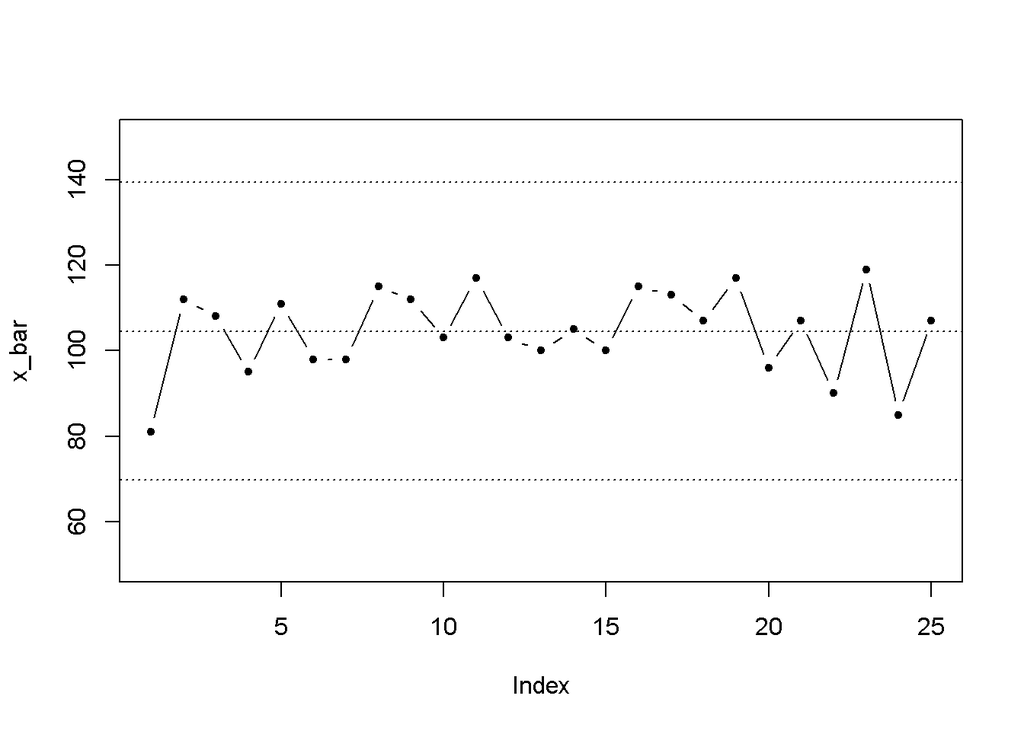

```r
sigma0_hat <- MR_bar/d2_2
x_bar <- mean(table_4e8[,"Systolic"])

UCL_X_bar <- x_bar + 3*sigma0_hat
CL_X_bar <- x_bar
LCL_X_bar <- x_bar - 3*sigma0_hat

plot(table_4e8[,"Systolic"], type="b", pch=20, ylab="x_bar", ylim=c(50,150))
abline(h=UCL_X_bar,lty="dotted")
abline(h=CL_X_bar,lty="dotted")
abline(h=LCL_X_bar,lty="dotted")
```

모든 MR statistic들이 [LCL,UCL] 사이에 있으므로 공정 상태는 In control이다.

# Question 6.58

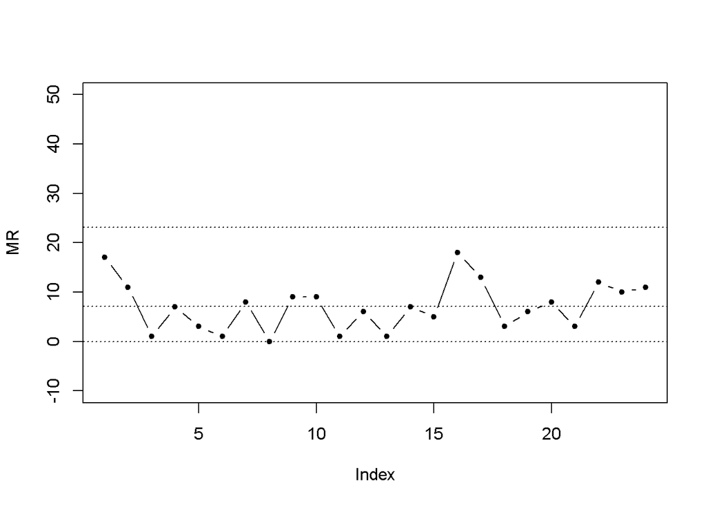

```r
MR <- abs(table_4e8[2:n,"Diastolic"] - table_4e8[1:(n-1),"Diastolic"])
MR_bar <- mean(MR)
UCL_MR <- MR_bar + 3*MR_bar*d3_2/d2_2
CL_MR <- MR_bar
LCL_MR <- max((MR_bar - 3*MR_bar*d3_2/d2_2),0)

plot(MR, type="b", pch=20, ylab="MR", ylim=c(-10,50))
abline(h=UCL_MR,lty="dotted")
abline(h=CL_MR,lty="dotted")
abline(h=LCL_MR,lty="dotted")
```

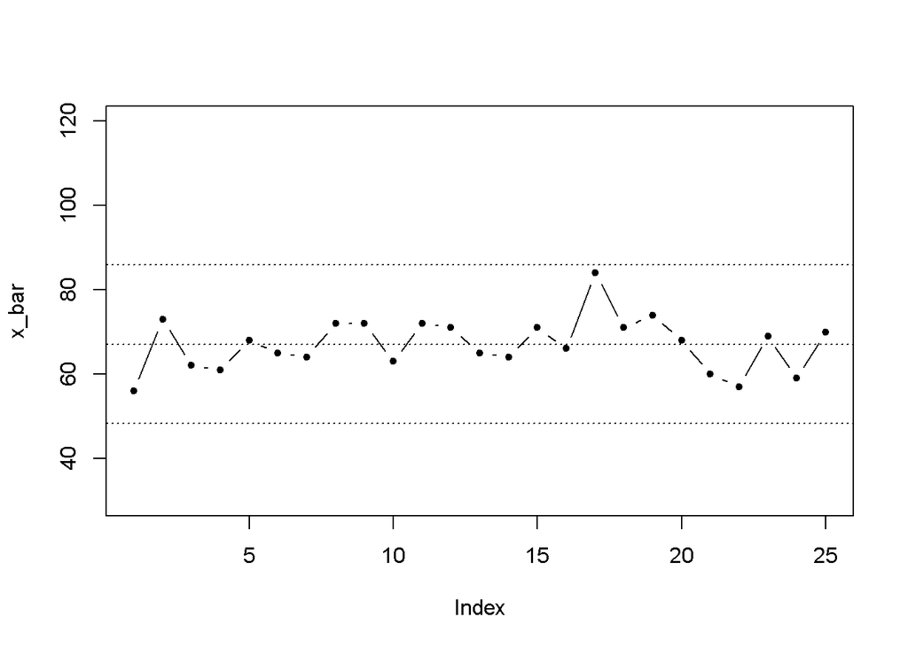

```r
sigma0_hat <- MR_bar/d2_2
x_bar <- mean(table_4e8[,"Diastolic"])

UCL_X_bar <- x_bar + 3*sigma0_hat
CL_X_bar <- x_bar
LCL_X_bar <- x_bar - 3*sigma0_hat

plot(table_4e8[,"Diastolic"], type="b", pch=20, ylab="x_bar", ylim=c(30,120))
abline(h=UCL_X_bar,lty="dotted")
abline(h=CL_X_bar,lty="dotted")
abline(h=LCL_X_bar,lty="dotted")
```

57번 문제에서 분석의 대상이 되는 대상을 Diastolic으로 바꾸고 동일한 과정을 거치면, 모든 MR statistic들이 [LCL,UCL] 사이에 있으므로 공정 상태는 In control이다.

# Question 6.59

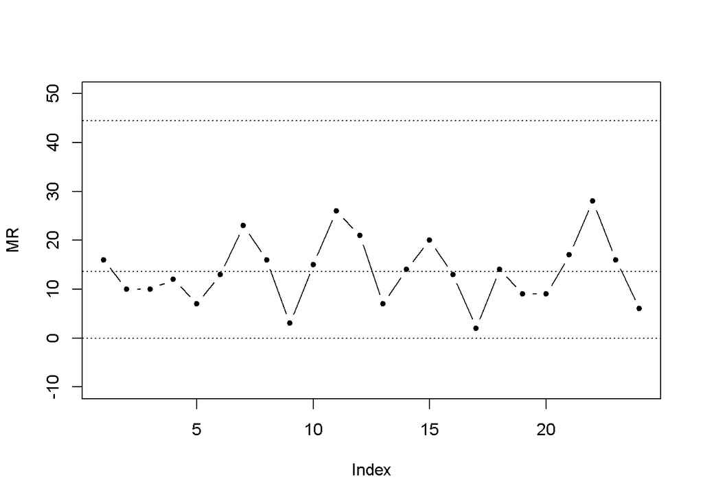

```r
MR <- abs(table_4e8[2:n,"PulseRate"] - table_4e8[1:(n-1),"PulseRate"])
MR_bar <- mean(MR)
UCL_MR <- MR_bar + 3*MR_bar*d3_2/d2_2
CL_MR <- MR_bar
LCL_MR <- max((MR_bar - 3*MR_bar*d3_2/d2_2),0)

plot(MR, type="b", pch=20, ylab="MR", ylim=c(-10,50))
abline(h=UCL_MR,lty="dotted")
abline(h=CL_MR,lty="dotted")
abline(h=LCL_MR,lty="dotted")
```

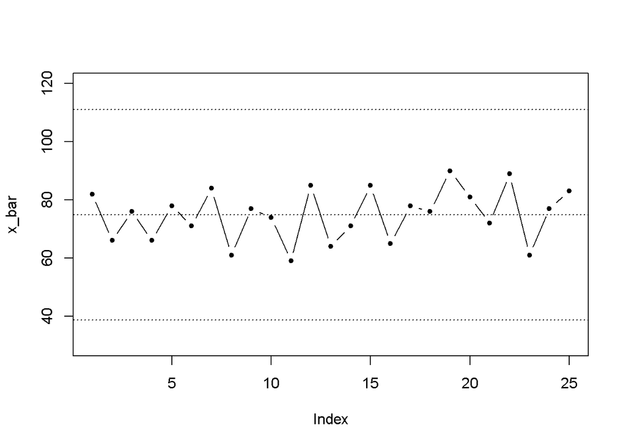

```r
sigma0_hat <- MR_bar/d2_2
x_bar <- mean(table_4e8[,"PulseRate"])

UCL_X_bar <- x_bar + 3*sigma0_hat
CL_X_bar <- x_bar
LCL_X_bar <- x_bar - 3*sigma0_hat

plot(table_4e8[,"PulseRate"], type="b", pch=20, ylab="x_bar", ylim=c(30,120))
abline(h=UCL_X_bar,lty="dotted")
abline(h=CL_X_bar,lty="dotted")
abline(h=LCL_X_bar,lty="dotted")
```

# Question 6.(i)

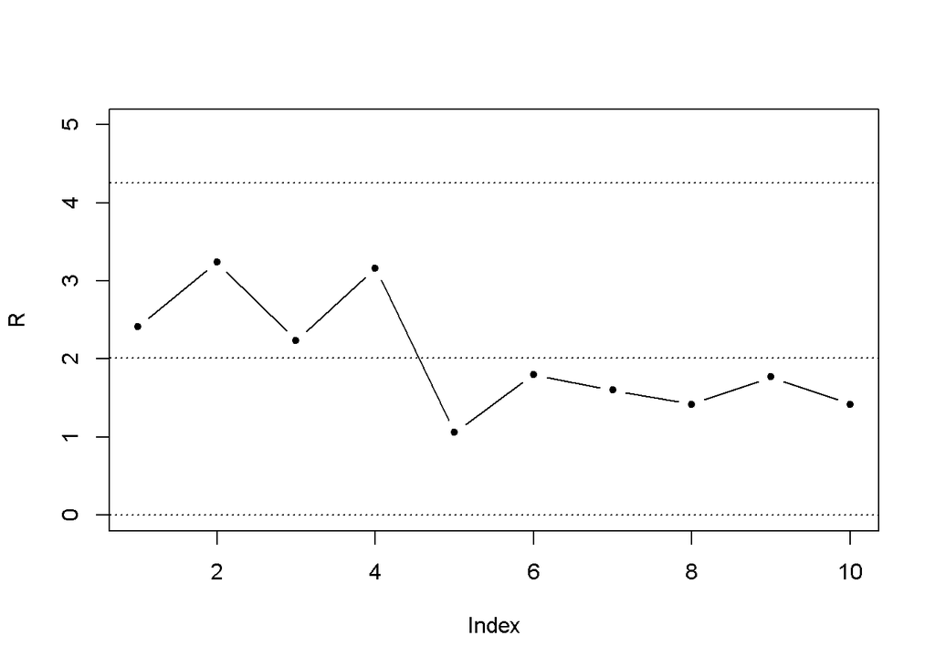

```r
table_6 <- matrix(c(
34.09,36.30,35.76,35.01,36.50,
36.11,34.39,35.15,36.76,37.63,
33.43,35.41,34.00,35.20,35.67,
36.79,35.96,35.62,34.48,33.63,
36.46,35.89,35.83,35.43,35.40,
33.59,34.76,33.98,34.35,35.39,
36.17,36.20,34.60,34.97,34.83,
34.66,35.05,36.08,34.99,35.15,
35.95,34.18,35.02,35.32,34.77,
35.62,35.18,34.93,36.35,36.24),
nrow=10,ncol=5,byrow="T")
n=5
d2_5 <- 2.326
d3_5 <- 0.864
R_bar <- mean(apply(table_6,1,rg))
sigma0_hat <- R_bar/d2_5

UCL_R <- R_bar + 3*sigma0_hat*d3_5
CL_R <- R_bar
LCL_R <- max((R_bar - 3*sigma0_hat*d3_5),0)

plot(apply(table_6,1,rg),type="b",pch=20,ylab="R",ylim=c(0,5))
abline(h=UCL_R,lty="dotted")
abline(h=CL_R,lty="dotted")
abline(h=LCL_R,lty="dotted")
```

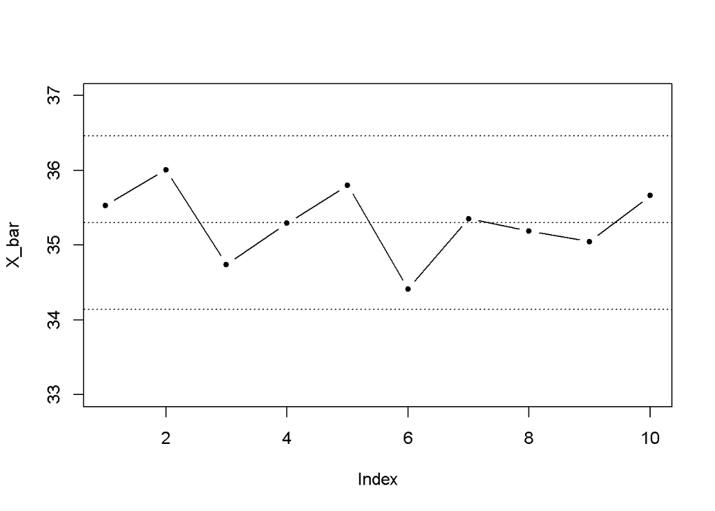

```r
x_barbar <- mean(apply(table_6,1,mean))
UCL_xbarbar <- x_barbar + 3*sigma0_hat/sqrt(n)
CL_xbarbar <- x_barbar
LCL_xbarbar <- x_barbar - 3*sigma0_hat/sqrt(n)

plot(apply(table_6,1,mean),type="b",pch=20,ylab="X_bar",ylim=c(33,37))
abline(h=UCL_xbarbar,lty="dotted")
abline(h=CL_xbarbar,lty="dotted")
abline(h=LCL_xbarbar,lty="dotted")
```

alpha=0.0027은 L=3과 같으므로 3sigma rule을 적용하면 된다. x_bar, R chart 각각 모든 sample 특성치가 각 chart의 [LCL,UCL] 구간에 속하므로 공정은 In Control 상태이다.

# Question 6.(ii)

```r
x_barbar
```

```
## [1] 35.3046
```

```r
sigma0_hat
```

```
## [1] 0.8650043
```

```r
1/sigma0_hat
```

```
## [1] 1.156064
```

(i)에서 구한 값에 의하여 mu0의 estimator=x_barbar=35.3046 sigma0의 estimator=sigma0_hat=0.865

# Question 6.(iii)

(i)에서 설정한 alpha-error=0.0027에서 alpha-error= Pr(Decide Process is out of control given Process is In Control) =Pr(new sample give a signal of mean shift given process mean is not shifted)이므로 구하는 값은 0.0027이다.

# Question 6.(iv)

```r
k=1/sigma0_hat
beta <- pnorm(3-k*sqrt(n)) - pnorm(-3-k*sqrt(n))
ARL_1 <- 1/(1-beta)
ARL_1
```

```
## [1] 2.949118
```

Shewhart Control Chart에서 ARL_0 = 1/alpha로 alpha=0.0027에서 값은 370이다. ARL_1을 구하기 위해 beta-error을 구하면 beta-error = Pr(Decide Process is In control given Process is Out of control)로, k=abs(mean shift)/sigma0= sigma0를 앞서 구한 추정치로 plug-in하여 1/sigma0_hat= 1.156, 그리고 alpha=0.0027일 때 z=3이므로 간단히 정리하면 beta는 위 코드의 수식으로 표현되고 ARL_1 = 1/(1-beta)=2.95로 계산된다.

# Question 7.(i)

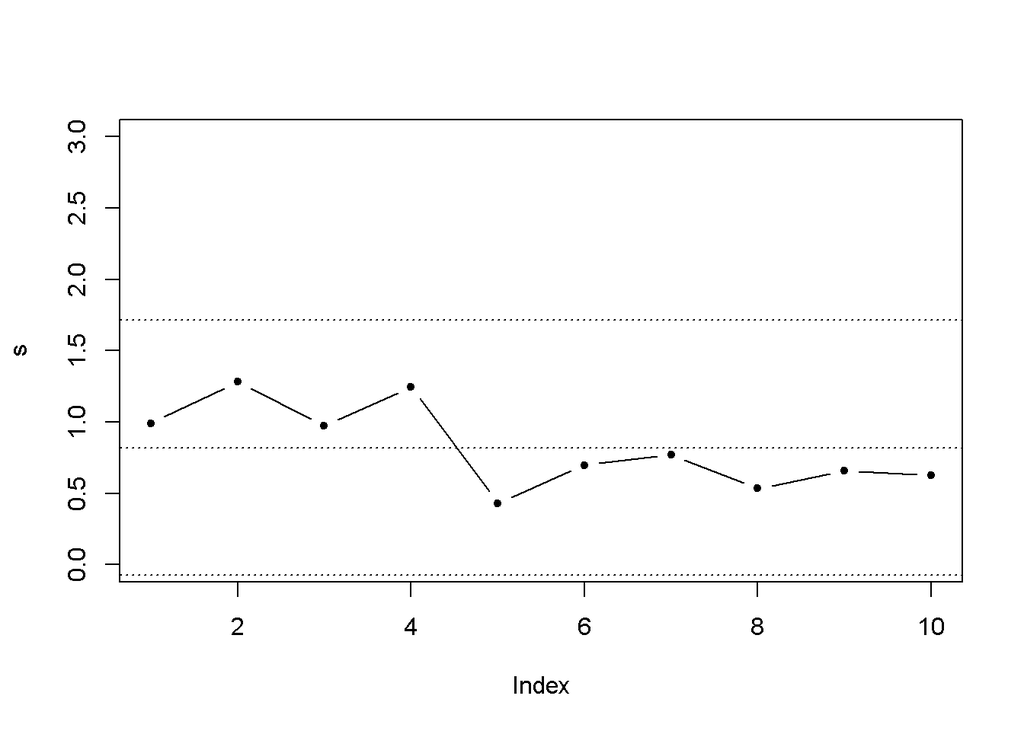

```r
c4_5 <- 0.9400
s_bar <- mean(apply(table_6,1,sd))

UCL_s <- s_bar + 3*s_bar*sqrt(1-c4_5^2)/c4_5
CL_s <- s_bar
LCL_s <- s_bar - 3*s_bar*sqrt(1-c4_5^2)/c4_5

plot(apply(table_6,1,sd),type="b",pch=20,ylab="s",ylim=c(0,3))
abline(h=UCL_s,lty="dotted")
abline(h=CL_s,lty="dotted")
abline(h=LCL_s,lty="dotted")
```

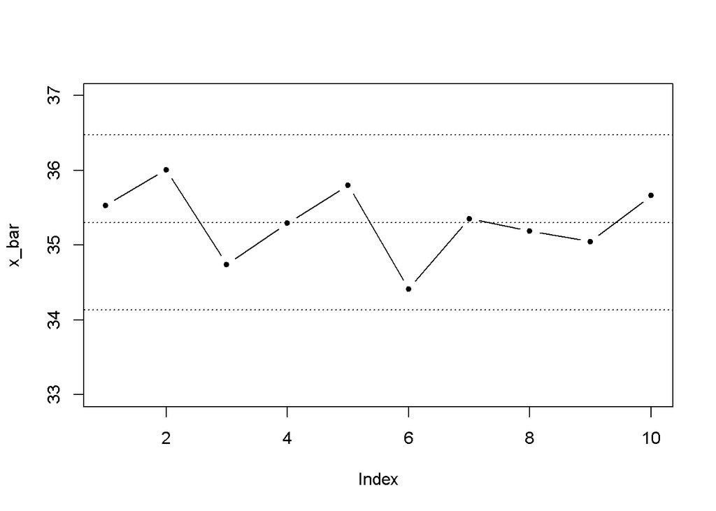

```r
UCL_xbar <- x_barbar + 3*(s_bar/c4_5)/sqrt(n)
CL_xbar <- x_barbar
LCL_xbar <- x_barbar - 3*(s_bar/c4_5)/sqrt(n)

plot(apply(table_6,1,mean),type="b",pch=20,ylab="x_bar",ylim=c(33,37))
abline(h=UCL_xbar,lty="dotted")
abline(h=CL_xbar,lty="dotted")
abline(h=LCL_xbar,lty="dotted")
```

X_bar, s chart 모두 sample 특성치가 각각의 [LCL, UCL] 구간에 모두 포함되므로 In control 상태이다.

# Question 7.(ii)

```r
sigma0_hat <- c(R_bar/d2_5, s_bar/c4_5,sd(table_6))

sigma0_hat
```

```
## [1] 0.8650043 0.8729715 0.9098513
```

문제에서 요구한 3가지 다른 방법의 sigma 추정법을 이용해 구한 추정치는 대략 0.865, 0.873, 0.910으로 큰 차이는 나지 않는 것으로 보인다. 모든 sample을 하나의 sample 덩어리로 생각하는 경우를 sample index별로 stratifying한다는 관점에서 볼 때 stratification 효과를 고려하지 않은 추정치라고 볼 수 있다. R과 s를 이용한 sigma 추정 방법을 비교한다면, 일반적으로 r과 s 통계량의 robustness와 가설 검정의 power가 다르므로 데이터의 robust와 testing power를 모두 고려하여 어떤 통계량을 고를 지를 결정할지 판단하여야 한다.

# Question 8.(i)

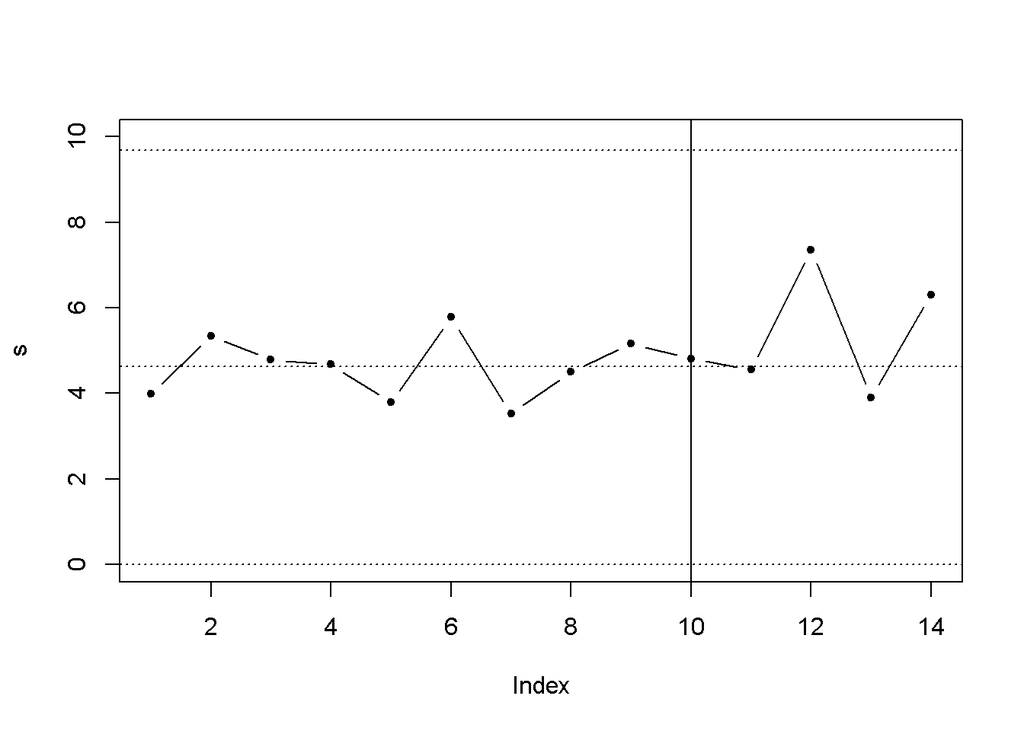

```r
xbar <- c(80.22,78.31,81.40,78.53,81.32,80.54,77.33,79.24,81.44,77.76,79.48,76.74,81.12,86.79)
sd <- c(3.99,5.35,4.79,4.68,3.79,5.78,3.52,4.51,5.16,4.81,4.56,7.35,3.91,6.31)

n <- 5
m <- 10

c4_5 <- 0.9400
s_bar <- mean(sd[1:m])
x_barbar <- mean(xbar[1:m])

UCL_s <- s_bar + 3*(sqrt(1-c4_5^2)/c4_5)*s_bar
CL_s <- s_bar
LCL_s <- max(0,s_bar - 3*(sqrt(1-c4_5^2)/c4_5)*s_bar)

plot(sd,type="b",pch=20,ylab="s",ylim=c(0,10))
abline(h=UCL_s,lty="dotted")
abline(h=CL_s,lty="dotted")
abline(h=LCL_s,lty="dotted")
abline(v=10)
```

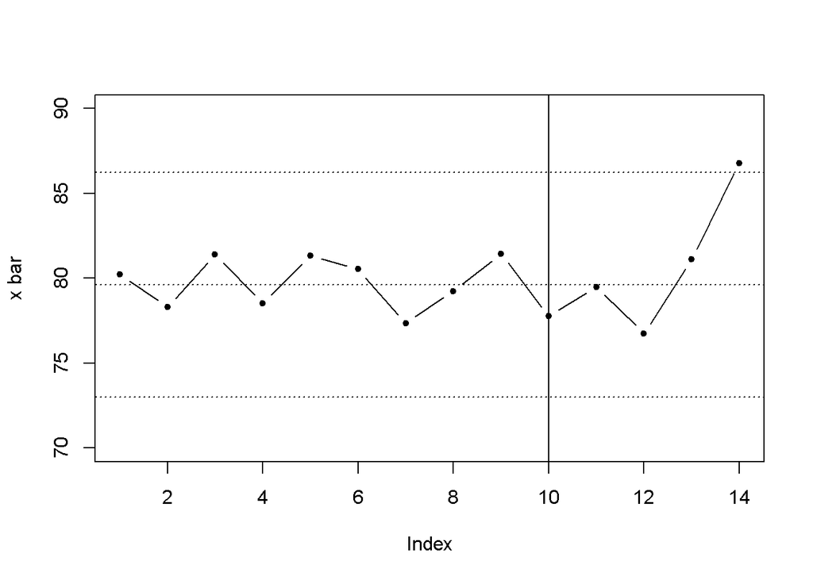

```r
UCL_xbar <- x_barbar + 3*(s_bar/c4_5)/sqrt(n)
CL_xbar <- x_barbar
LCL_xbar <- x_barbar - 3*(s_bar/c4_5)/sqrt(n)

plot(xbar,type="b",pch=20,ylab="x bar",ylim=c(70,90))
abline(h=UCL_xbar,lty="dotted")
abline(h=CL_xbar,lty="dotted")
abline(h=LCL_xbar,lty="dotted")
abline(v=10)
```

# Question 8.(ii)

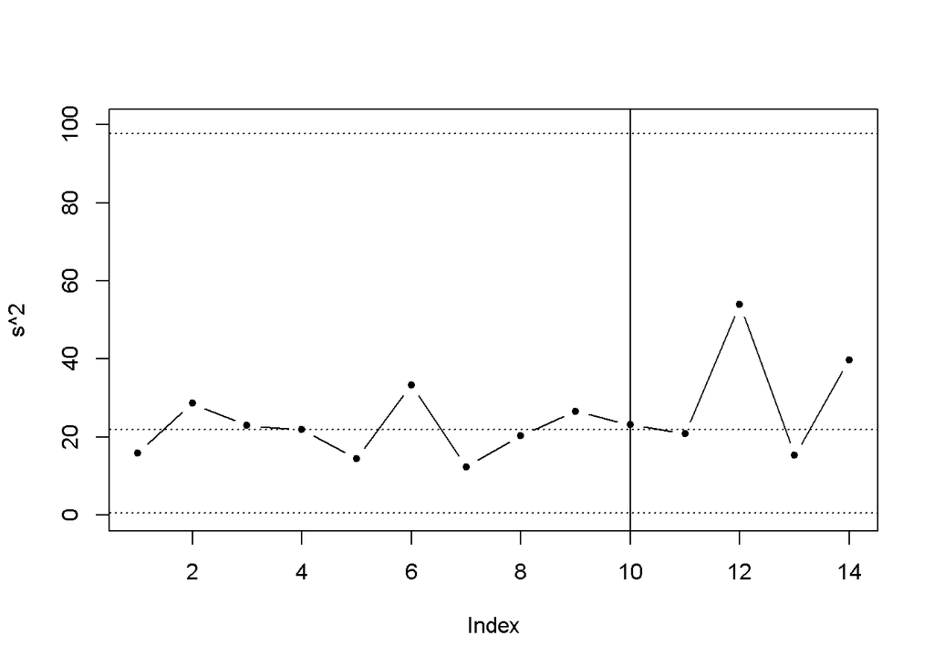

```r
s2 <- sd^2
s2_bar <- mean(s2[1:m])
alpha <- 0.0027

UCL_s2 <- qchisq(1-alpha/2,df=n-1)*s2_bar/(n-1)
CL_s2 <- s2_bar
LCL_s2 <- qchisq(alpha/2,df=n-1)*s2_bar/(n-1)

plot(s2,type="b",pch=20,ylab="s^2",ylim=c(0,100))
abline(h=UCL_s2,lty="dotted")
abline(h=CL_s2,lty="dotted")
abline(h=LCL_s2,lty="dotted")
abline(v=10)
```

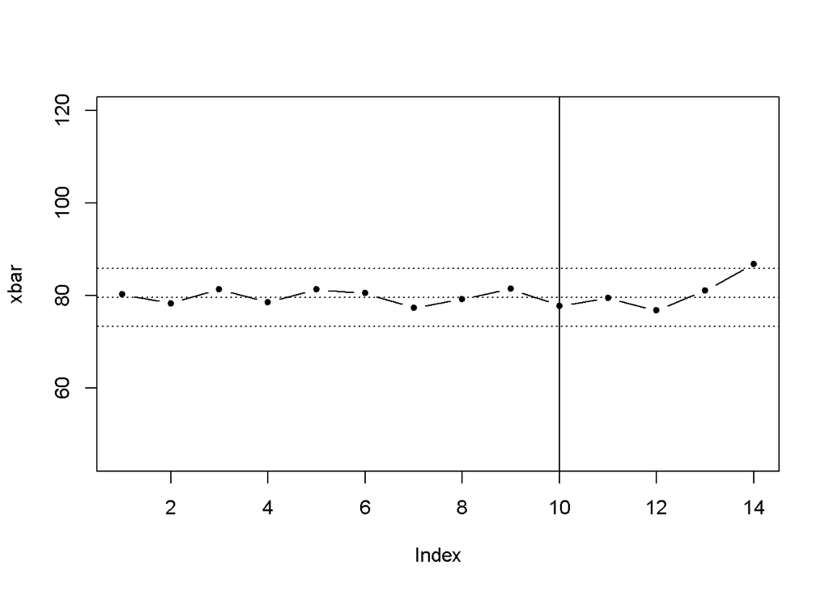

```r
UCL_xbar <- x_barbar + 3*sqrt(s2_bar)/sqrt(n)
CL_xbar <- x_barbar
LCL_xbar <- x_barbar - 3*sqrt(s2_bar)/sqrt(n)

plot(xbar,type="b",pch=20,ylab="xbar",ylim=c(45,120))
abline(h=UCL_xbar,lty="dotted")
abline(h=CL_xbar,lty="dotted")
abline(h=LCL_xbar,lty="dotted")
abline(v=10)
```

xbar chart에서 Phase II에 해당하는 14번째 데이터가 UCL을 벗어났다. 따라서, Phase II 공정으로부터 out of control(mu0 shifting) 상태임을 알 수 있다.

# Question 8.(iii)

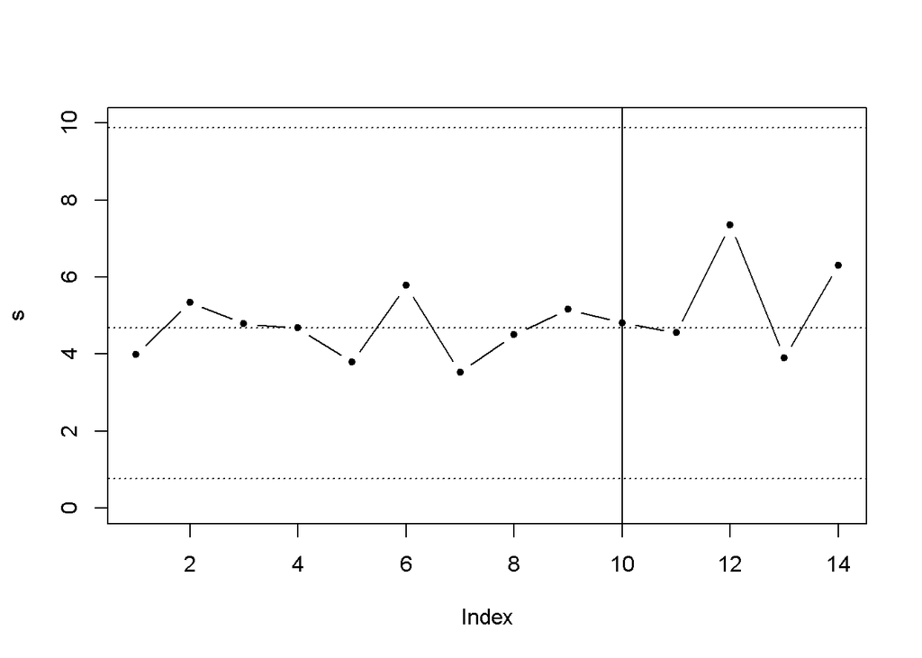

```r
UCL_s_s2 <-sqrt(UCL_s2)
CL_s_s2 <-sqrt(CL_s2)
LCL_s_s2 <-sqrt(LCL_s2)

plot(sd,type="b",pch=20,ylab="s",ylim=c(0,10))
abline(h=UCL_s_s2,lty="dotted")
abline(h=CL_s_s2,lty="dotted")
abline(h=LCL_s_s2,lty="dotted")
abline(v=10)
```

(i)에서 구한 s의 UCL, CL, LCL을 s^2 추정량을 이용한 UCL, CL, LCL의 square root로 치환하여 새로운 3개의 line을 구하였다. 모든 sample 특성치가 [LCL, UCL] 안에 들어있으며 (i)과 비교 동일한 결과를 얻을 수 있다.

# Question 9.(i)

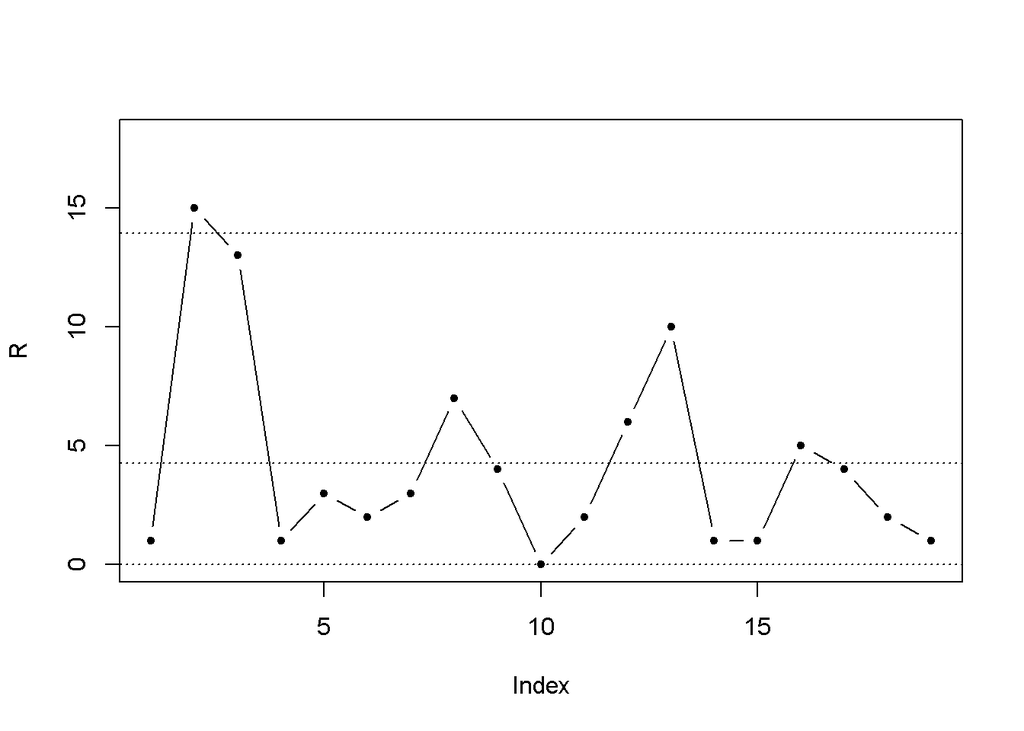

```r
data9 <- c(25,24,39,26,25,22,24,21,28,24,24,22,16,26,25,26,21,25,23,24)
m <- length(data9)
n <- 2
data9_rm <- do.call("rbind", lapply(1:(m-n+1),function(i){
  return(data9[i:(i+n-1)])
}))

d2_2 <- 1.128
d3_2 <- 0.853
R_bar <- mean(apply(data9_rm,1,rg))
sigma0_hat <- R_bar/d2_2

UCL_R <- R_bar + 3*sigma0_hat*d3_2
CL_R <- R_bar
LCL_R <- max((R_bar - 3*sigma0_hat*d3_2),0)

plot(apply(data9_rm,1,rg),type="b",pch=20,ylab="R",ylim=c(0,18))
abline(h=UCL_R,lty="dotted")
abline(h=CL_R,lty="dotted")
abline(h=LCL_R,lty="dotted")
```

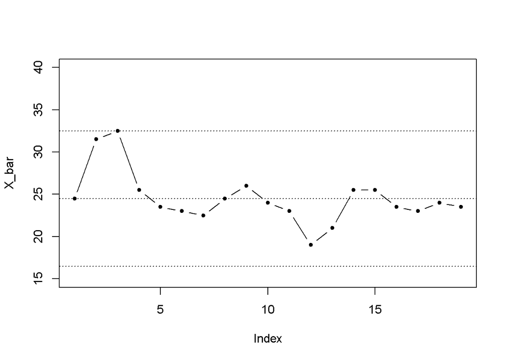

```r
x_barbar <- mean(apply(data9_rm,1,mean))
UCL_xbarbar <- x_barbar + 3*sigma0_hat/sqrt(n)
CL_xbarbar <- x_barbar
LCL_xbarbar <- x_barbar - 3*sigma0_hat/sqrt(n)

plot(apply(data9_rm,1,mean),type="b",pch=20,ylab="X_bar",ylim=c(15,40))
abline(h=UCL_xbarbar,lty="dotted")
abline(h=CL_xbarbar,lty="dotted")
abline(h=LCL_xbarbar,lty="dotted")
```

etl 영상에 소개되어 있는 do.call 함수를 이용하여 RM을 원소로 하는 matrix를 만들었다. n=2일 때, 원소가 RM인 matrix를 만들고 R chart와 x chart를 구하면, R chart에서 sample 1개가 UCL을 벗어난다. 따라서 공정은 out of control 상태라고 판단할 수 있다.

# Question 9.(ii)

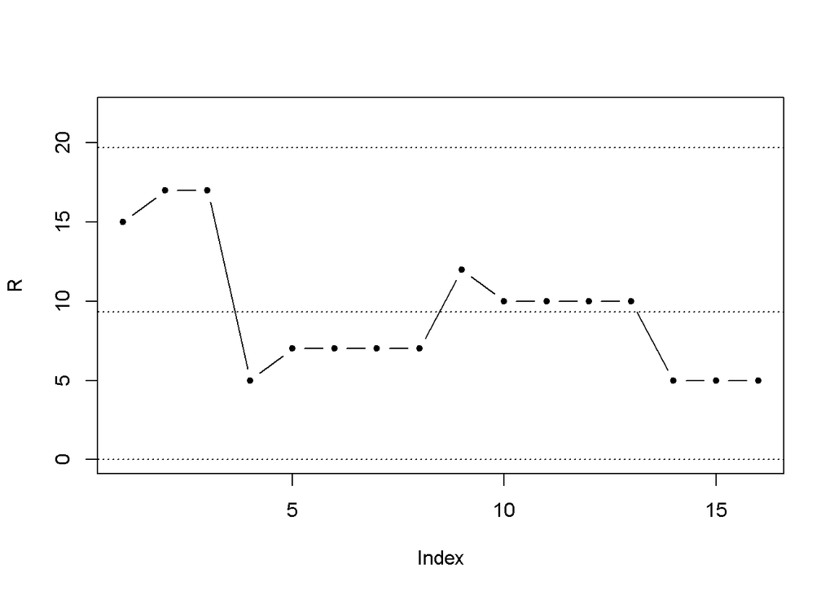

```r
n <- 5
data9_rm <- do.call("rbind", lapply(1:(m-n+1),function(i){
  return(data9[i:(i+n-1)])
}))

d2_5 <- 2.326
d3_5 <- 0.864
R_bar <- mean(apply(data9_rm,1,rg))
sigma0_hat <- R_bar/d2_5

UCL_R <- R_bar + 3*sigma0_hat*d3_5
CL_R <- R_bar
LCL_R <- max((R_bar - 3*sigma0_hat*d3_5),0)

plot(apply(data9_rm,1,rg),type="b",pch=20,ylab="R",ylim=c(0,22))
abline(h=UCL_R,lty="dotted")
abline(h=CL_R,lty="dotted")
abline(h=LCL_R,lty="dotted")
```

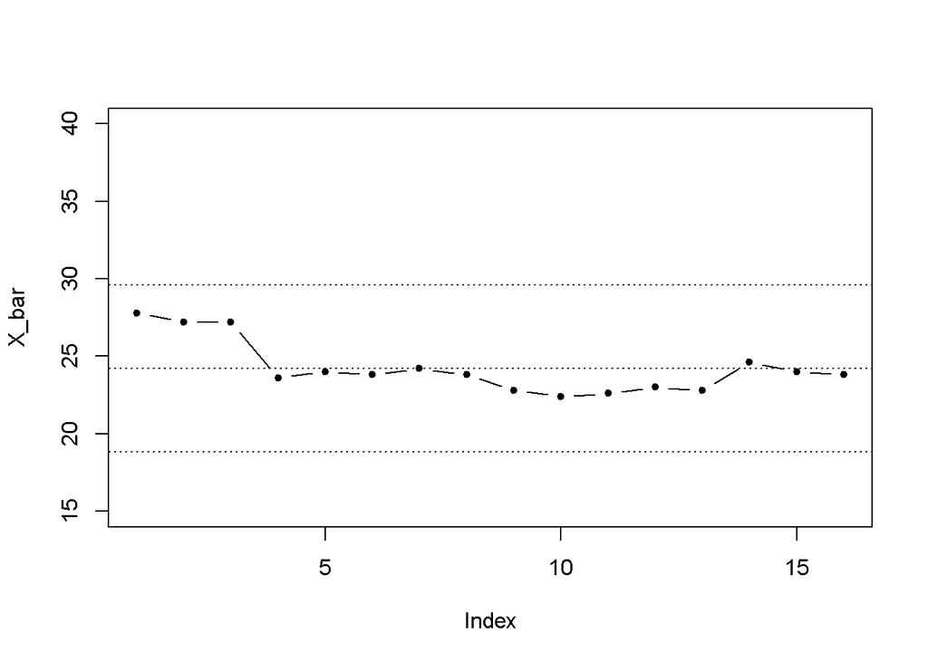

```r
x_barbar <- mean(apply(data9_rm,1,mean))
UCL_xbarbar <- x_barbar + 3*sigma0_hat/sqrt(n)
CL_xbarbar <- x_barbar
LCL_xbarbar <- x_barbar - 3*sigma0_hat/sqrt(n)

plot(apply(data9_rm,1,mean),type="b",pch=20,ylab="X_bar",ylim=c(15,40))
abline(h=UCL_xbarbar,lty="dotted")
abline(h=CL_xbarbar,lty="dotted")
abline(h=LCL_xbarbar,lty="dotted")
```